# Raport

Wanesa Konkel, Adrianna Kluk, Filip Bieszke, Sebastian Gębczyk

2025-01-22

# WSTĘP

Rynek nieruchomości jest jednym z kluczowych obszarów, w których analityka danych znajduje szerokie zastosowanie. W ramach tego raportu zostaną przeanalizowane dane dotyczące wynajmu mieszkań w różnych miastach, aby zidentyfikować kluczowe czynniki wpływające na wysokość czynszu oraz przewidywać ceny wynajmu na podstawie dostępnych informacji.

## Opis danych

Zestaw danych składa się z 8849 obserwacji oraz 28 zmiennych, obejmujących zarówno cechy mieszkań, jak i ich lokalizację. Główne zmienne to:

- Metraż i układ mieszkania: squareMeters (powierzchnia w m²), rooms (liczba pokoi), floor (piętro), floorCount (liczba pięter w budynku).
- Lokalizacja: city (miasto), latitude i longitude (współrzędne geograficzne), centreDistance (odległość od centrum).
- Infrastruktura i otoczenie: schoolDistance, clinicDistance, restaurantDistance, collegeDistance (odległości do różnych punktów usługowych).
- Cechy budynku i mieszkania: buildYear (rok budowy), buildingMaterial (materiał budynku), condition (stan mieszkania), hasElevator, hasBalcony, hasParkingSpace, hasSecurity (cechy dodatkowe).
- Cena wynajmu: price (wysokość czynszu w PLN).

# ANALIZA BRAKÓW DANYCH

```
##                      na_counts
## id                           0
## city                         0
## type                      1830
## squareMeters                 0
## rooms                        0
## floor                     1053
## floorCount                 155
## buildYear                 2249
## latitude                     0
## longitude                    0
## centreDistance               0
## poiCount                     0
## schoolDistance               0
## clinicDistance               4
## postOfficeDistance           3
## kindergartenDistance         3
## restaurantDistance          16
## collegeDistance            112
## pharmacyDistance             7
## ownership                    0
## buildingMaterial          3505
## condition                 6329
## hasParkingSpace              0
## hasBalcony                   0
## hasElevator                496
## hasSecurity                  0
## hasStorageRoom               0
## price                        0
```

Powyzsza tabela przedstawia liczbe brakujacych danych w kazdej z badanych 28 zmiennych. Braki ukazane sa w ujeciu liczbowym. Zdecydowanie najwiecej brakow wystepuje w kolumnie zmiennej o nazwie condition, bo az 6329. Duza liczba brakow wyrozniaja sie takze zmienne: buildingMaterial (3505), buildYear (2249), type(1830) oraz floor(1053). Pozostale zmienne cechuja sie juz znacznie mniejsza liczba brakujacych danych. Pietnascie sposrod badanych zmiennych zawiera kompletne dane.

```
## [1] 15762
```

```
## [1] 232010
```

Łączna liczba brakow w calym analizowym zbiorze danych wynosi 15762, natomiast calkowita liczba kompletnych wartosci wynosi 232010. Zatem znaczna wiekszosc wartosci jest nam znana.

```
## # A tibble: 28 × 3
##    variable           n_miss pct_miss
##    <chr>               <int>    <num>
##  1 condition            6329  71.5
##  2 buildingMaterial     3505  39.6
##  3 buildYear            2249  25.4
##  4 type                 1830  20.7
##  5 floor                1053  11.9
##  6 hasElevator           496   5.61
##  7 floorCount            155   1.75
##  8 collegeDistance       112   1.27
##  9 restaurantDistance     16   0.181
## 10 pharmacyDistance        7   0.0791
## # ℹ 18 more rows
```

Powyzsza tabela ukazuje nie tylko wartosci liczbowe brakujacych danych w kazdej zmiennej, ale takze ich proporcje do lacznej sumy obserwacji. Poczawszy od wartosci posiadajac najmniej kompletnych danych.

```
##
## character   integer   numeric
##        11         1        16
```

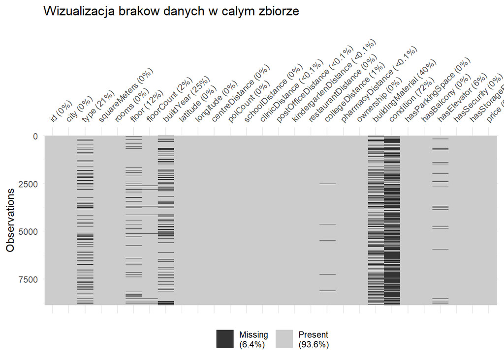

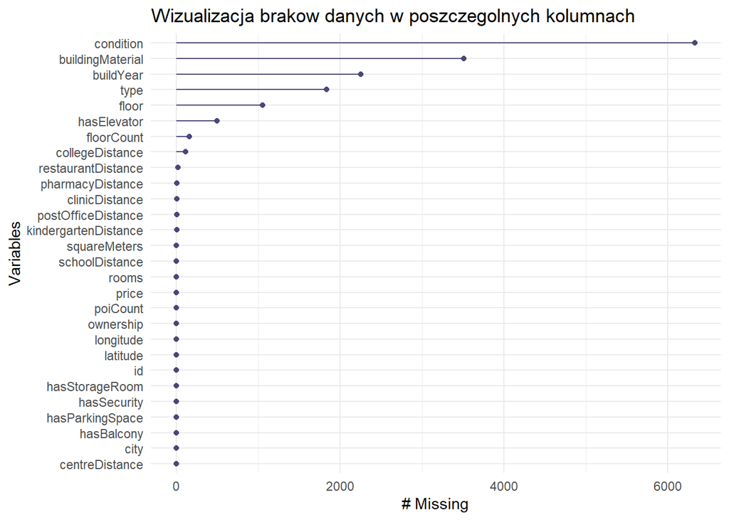

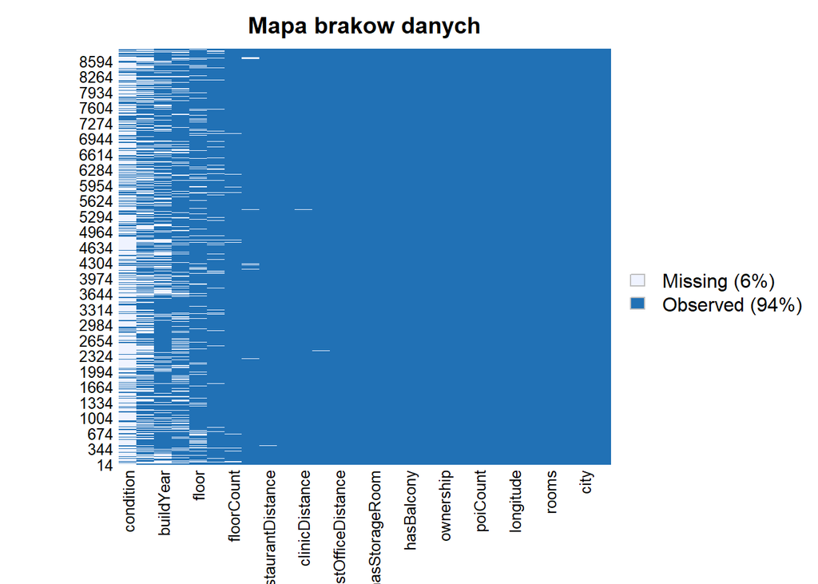

Takie braki mogą wynikać z kilku czynników, np. niekompletnych wpisów w bazach danych, błędów w rejestracji informacji czy nieobowiązkowego charakteru niektórych pól. Warto zauważyć, że zmienne geograficzne, takie jak “longitude” i “city”, są w pełni wypełnione, co sugeruje, że informacje lokalizacyjne są dobrze udokumentowane.

Możliwe metody radzenia sobie z brakami obejmują imputację wartości, co zostanie opisane w dalszej części raportu.

# WARTOŚCI ODSTAJĄCE

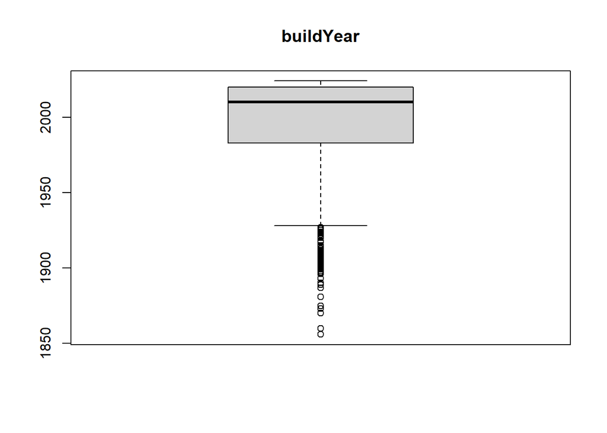

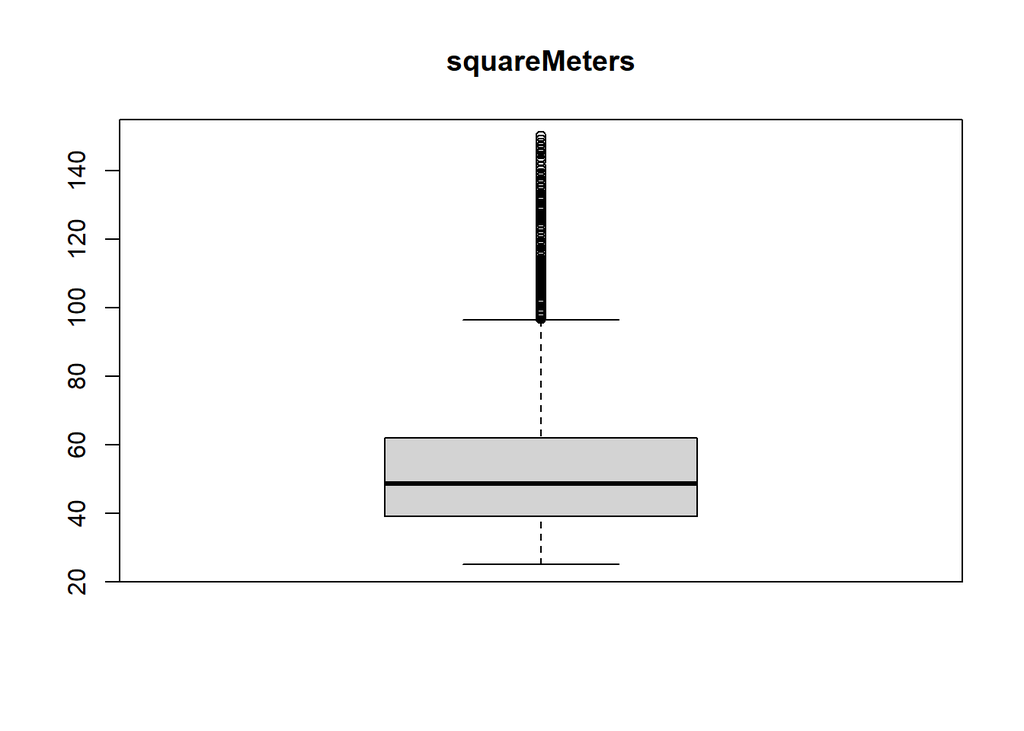

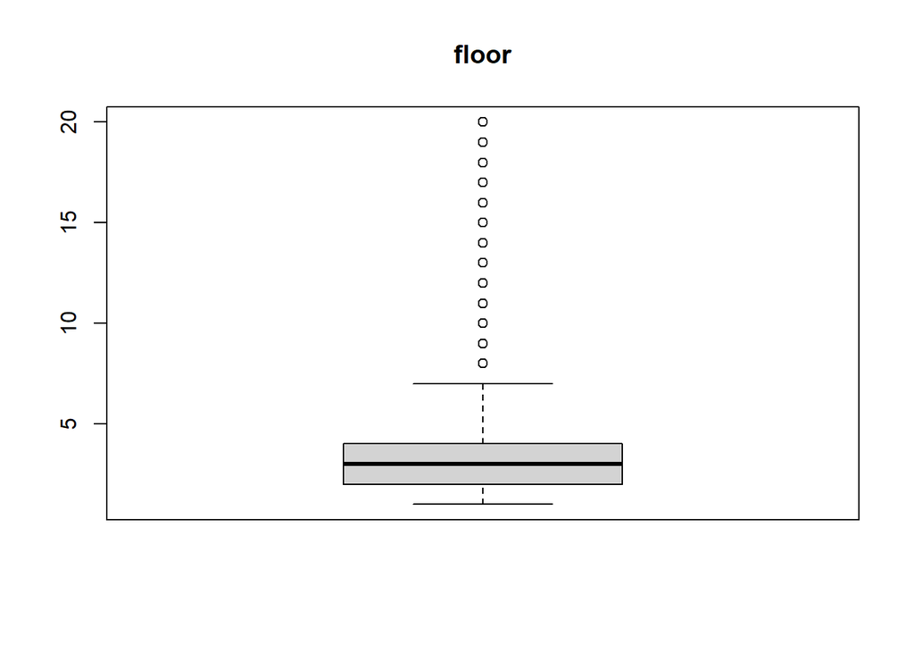

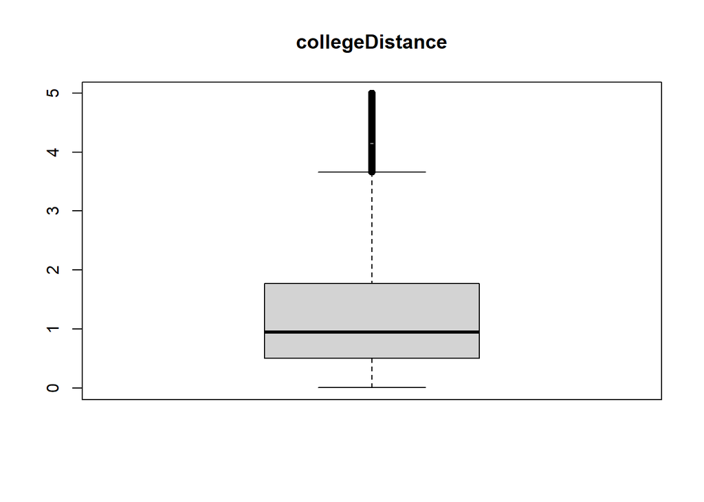

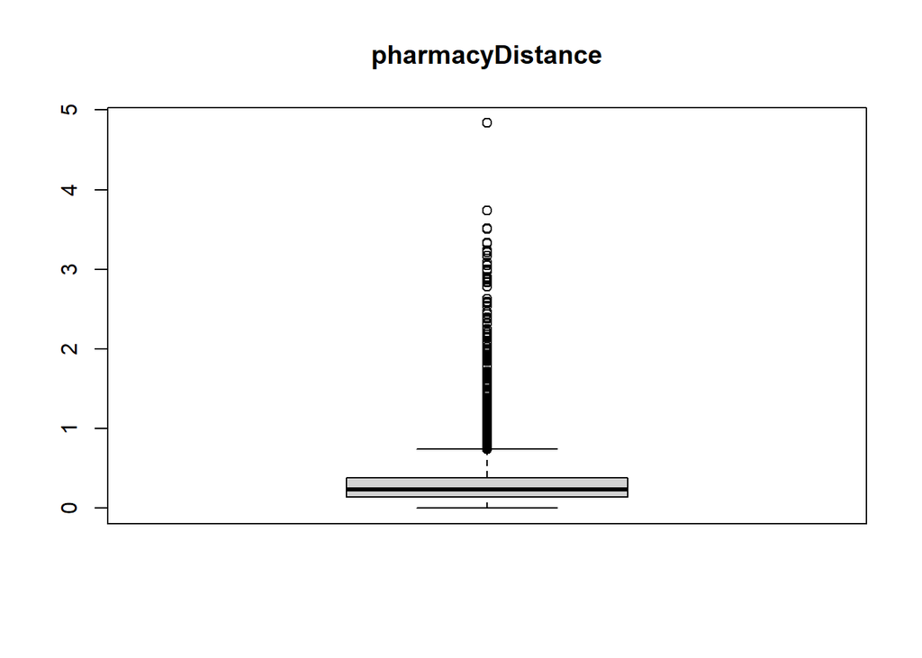

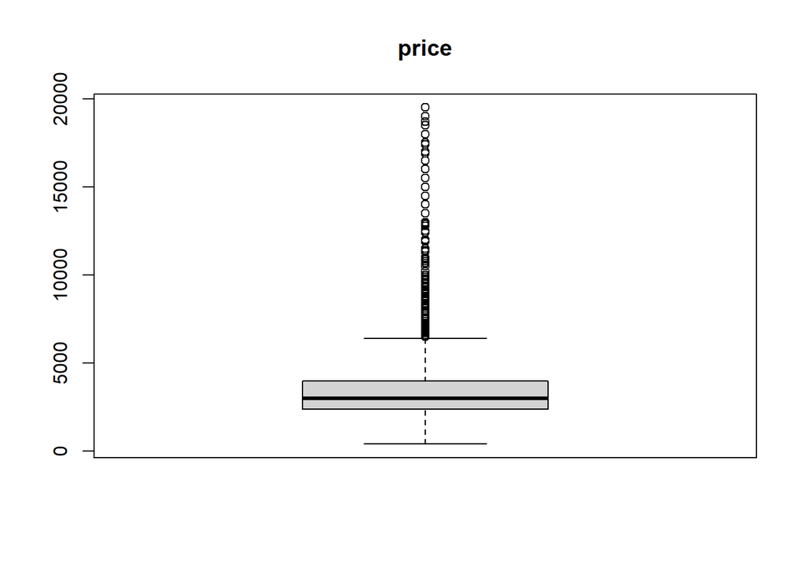

W analizowanym zbiorze danych wartości odstające występują w niemal każdej zmiennej. Jest to zjawisko naturalne w przypadku danych dotyczących nieruchomości, ponieważ rynek mieszkań charakteryzuje się dużą zmiennością wynikającą z różnic w lokalizacji, standardzie, metrażu oraz dostępności infrastruktury.

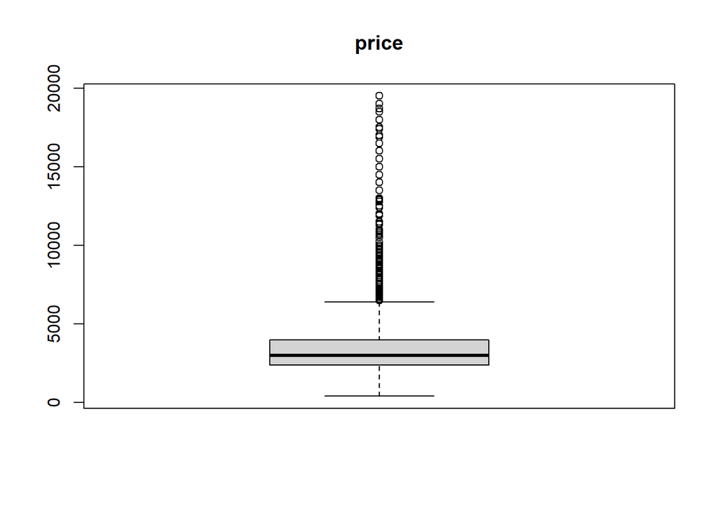

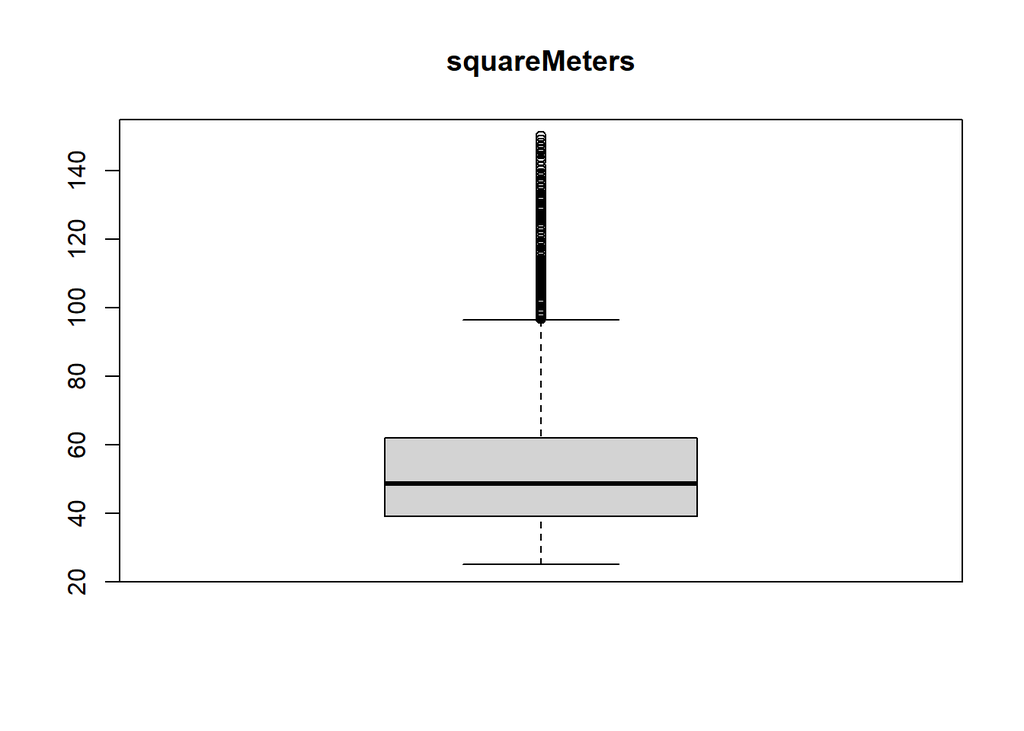

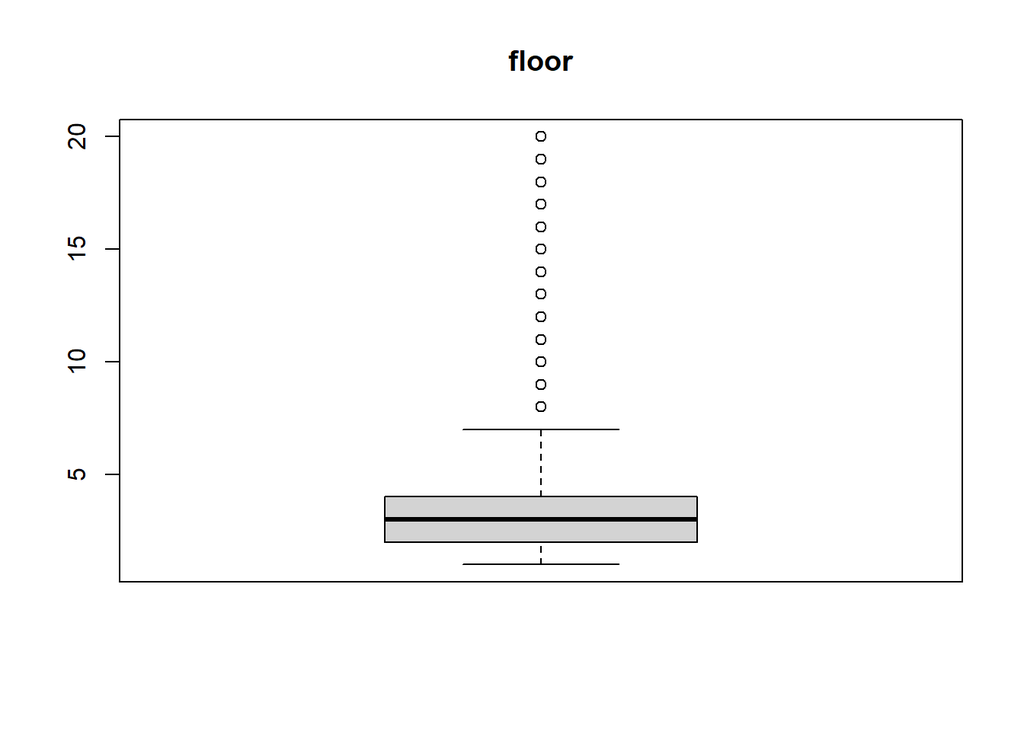

# WALIDACJA DANYCH

Przeprowadzono walidację danych dla zbioru `apartments_rent_pl_2024_06`. Zweryfikowano m.in. poprawność wartości liczbowych, spójność danych oraz unikalność wartości w kolumnach kategorycznych.

1. Zamiana pustych wartości na NA

Wszystkie puste wartości w zbiorze danych zamieniono na `NA`, co ułatwia dalszą analizę.

2. W ramach przeprowadzonej walidacji danych dotyczących mieszkań do wynajęcia w Polsce (zbiór danych `apartments_rent_pl_2024_06`) wykonano szczegółowe sprawdzenie poprawności zakresów i wartości dla czterech kluczowych zmiennych: metrażu (`squareMeters`), liczby pokoi (`rooms`), piętra (`floor`) oraz ceny (`price`). Każda z tych zmiennych została poddana indywidualnej analizie w celu wykrycia potencjalnych błędów lub nieprawidłowości.

**Metraż (`squareMeters`)**: Sprawdzono, czy wartości metrażu są dodatnie. W tym celu wyselekcjonowano rekordy, gdzie `squareMeters` było mniejsze lub równe zero. Nie znaleziono żadnych przypadków, co oznacza, że wszystkie mieszkania mają poprawny, dodatni metraż.

**Liczba pokoi (`rooms`)**: Przeanalizowano, czy liczba pokoi jest dodatnią liczbą całkowitą. Wyselekcjonowano rekordy, gdzie `rooms` było mniejsze lub równe zero lub nie było liczbą całkowitą. Nie znaleziono błędów, co potwierdza, że wszystkie wartości liczby pokoi są poprawne.

**Piętro (`floor`)**: Sprawdzono, czy piętro, na którym znajduje się mieszkanie, nie przekracza łącznej liczby pięter w budynku (`floorCount`). Wyselekcjonowano rekordy, gdzie `floor` było większe niż `floorCount`. Nie znaleziono takich przypadków, co wskazuje, że dane dotyczące pięter są spójne.

**Cena (`price`)**: Przeanalizowano, czy ceny mieszkań są dodatnie. Wyselekcjonowano rekordy, gdzie `price` było mniejsze lub równe zero. Nie znaleziono błędów, co potwierdza, że wszystkie ceny są dodatnie.

3. Sprawdzenie unikalnych wartości dla kolumn kategorycznych

W kolejnym etapie analizy danych skupiono się na sprawdzeniu unikalnych wartości dla kolumn kategorycznych w zbiorze danych `apartments_rent_pl_2024_06`. Przeanalizowano cztery kolumny: `type`, `ownership`, `condition` oraz `buildingMaterial`.

**Typ nieruchomości (`type`)**: Wyodrębniono unikalne wartości w kolumnie `type`, które określają rodzaj mieszkania. Wynikiem tej operacji jest lista unikalnych kategorii, które występują w danych.

**Forma własności (`ownership`)**: Sprawdzono unikalne wartości w kolumnie `ownership`, które opisują formę własności nieruchomości. Uzyskano listę wszystkich możliwych opcji w tej kategorii.

**Stan nieruchomości (`condition`)**: Przeanalizowano unikalne wartości w kolumnie `condition`, które opisują stan techniczny mieszkania. Wynikiem jest lista dostępnych stanów nieruchomości.

**Materiał budynku (`buildingMaterial`)**: Sprawdzono unikalne wartości w kolumnie `buildingMaterial`, które określają materiał, z którego wykonany jest budynek. Uzyskano listę wszystkich materiałów występujących w danych.

Analiza ta pozwala na lepsze zrozumienie struktury danych oraz identyfikację ewentualnych nieoczekiwanych lub nieprawidłowych kategorii w kolumnach kategorycznych, które w naszym przypadku się nie pojawiły.

# IMPUTACJA BRAKÓW DANYCH

W projekcie imputacja brakujących danych była kluczowym etapem przygotowania zbioru danych do dalszej analizy. Imputacja jest ważna, ponieważ brakujące dane mogą wprowadzać błędy i utrudniać rzetelne przeprowadzanie analiz. Zamiast ignorować lub usuwać wiersze z brakującymi wartościami, które mogłyby zniekształcić wyniki, zastosowano metodę imputacji, aby zastąpić brakujące wartości oszacowanymi danymi, zachowując spójność i pełność zestawu danych.

Pierwszym krokiem było zamienienie pustych wartości w zbiorze danych na NA, co umożliwiło dalsze operacje imputacyjne. Dla zmiennych liczbowych, takich jak powierzchnia mieszkania, liczba pięter czy odległości do punktów użyteczności publicznej, zastosowano metodę imputacji przy użyciu algorytmu MICE (Multiple Imputation by Chained Equations) i metody pmm (Predictive Mean Matching). Ta technika pozwala na dokładne uzupełnienie brakujących danych na podstawie obserwacji o podobnych wartościach.

Z kolei dla zmiennych kategorycznych, takich jak typ budynku, stan mieszkania czy dostępność udogodnień (np. parking czy balkon), wykorzystano metodę Hotdeck. Polega ona na imputacji brakujących wartości na podstawie najbardziej podobnych rekordów w danych, co jest szczególnie skuteczne w przypadku zmiennych o charakterze jakościowym.

Na koniec przeprowadzono analizę braków danych w zbiorze, aby ocenić skuteczność imputacji i upewnić się, że brakujące wartości zostały odpowiednio uzupełnione. Cały proces zakończył się zapisaniem wynikowego zbioru danych do pliku CSV.

Dzięki imputacji, dane stały się kompletne i gotowe do dalszych analiz.

# WIZUALIZACJA DANYCH

Odpowiednio przygotowane dane pozwolą na zilustowanie ich charakterystyk i rozkładów. Poniżej przedstawione zostały wybrane wizualizacje badanych danych

1. **Średnie wartości cen wynajmu w Polsce - mapa**

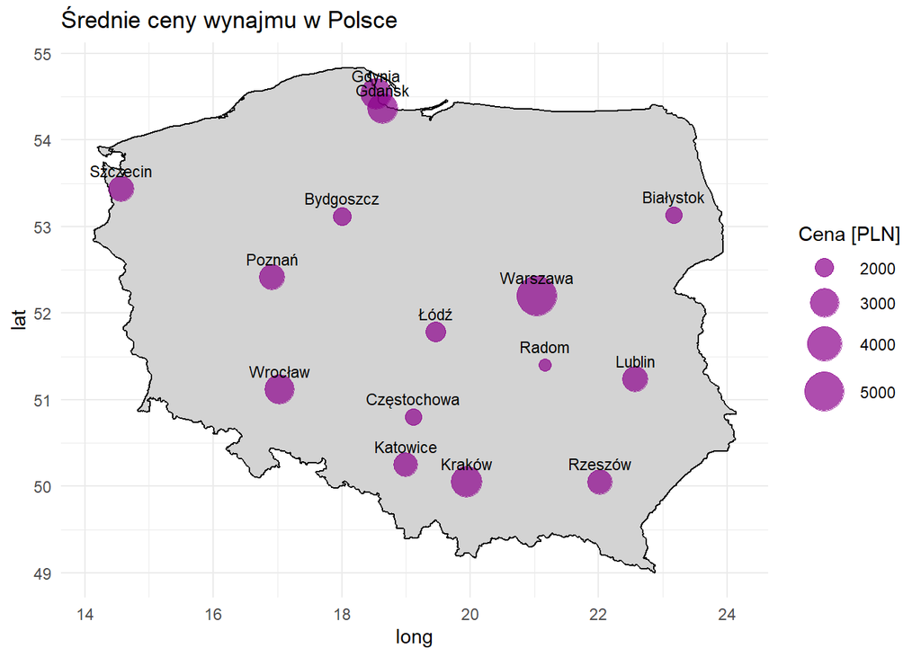

Warszawa wyróżnia się najwyższymi średnimi cenami wynajmu w Polsce, co wynika z jej roli gospodarczego i edukacyjnego centrum kraju. Duże miasta, takie jak Gdańsk, Kraków czy Wrocław, również odnotowują wysokie koszty, głównie ze względu na turystykę i rozwój biznesowy. W mniejszych miastach, takich jak Radom czy Białystok, ceny są znacznie niższe, co może wynikać z mniejszego popytu i ograniczonej urbanizacji.

2. **Rozkłady**
1. rozkład liczby pokoi

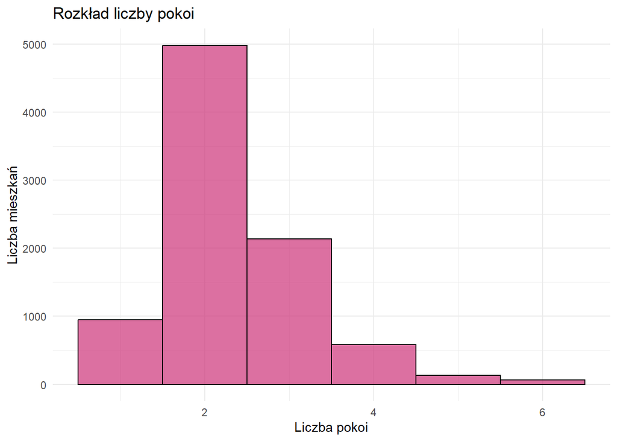

Wykres przedstawia rozkład liczby pokoi w mieszkaniach dostępnych na wynajem. Najwięcej ofert dotyczy mieszkań dwupokojowych, które dominują na rynku, co może wynikać z ich uniwersalności i popularności wśród wynajmujących. Mieszkania jednopokojowe i trzypokojowe stanowią mniejszą, choć znaczną część rynku, sugerując zróżnicowanie potrzeb najemców. Mieszkania cztero- i więcej pokojowe są rzadkością, co może oznaczać ograniczoną dostępność takich lokali lub niski popyt w tej kategorii.

2. liczba mieszkań z windą i bez windy w różnych miastach

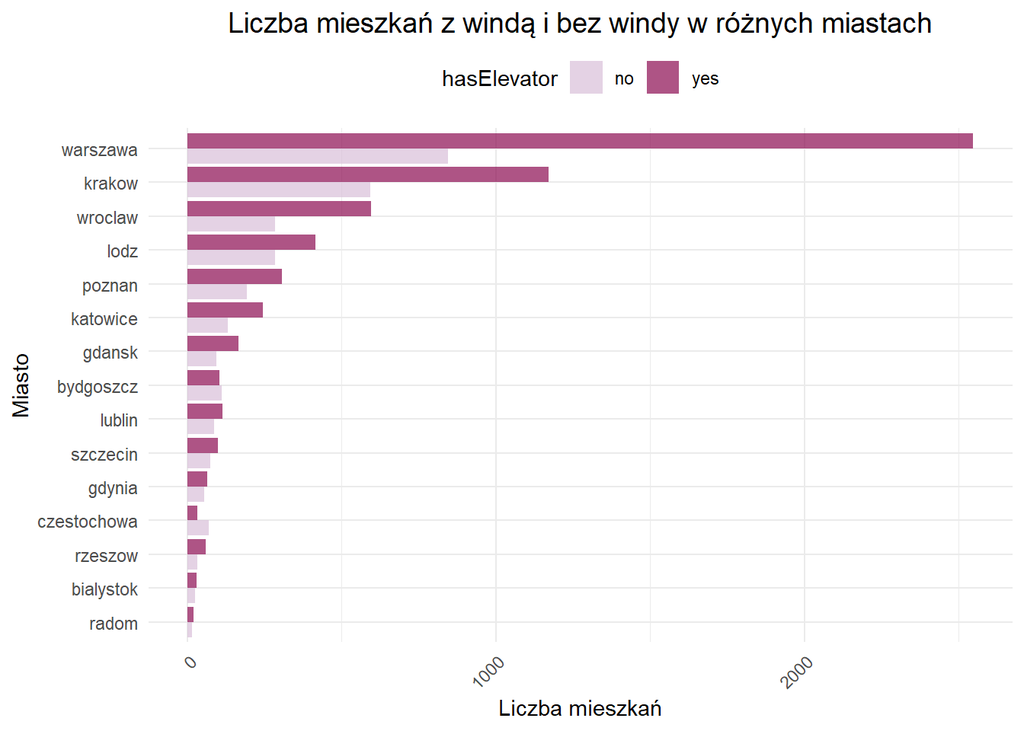

3. Liczba mieszkań w poszczególnych miastach

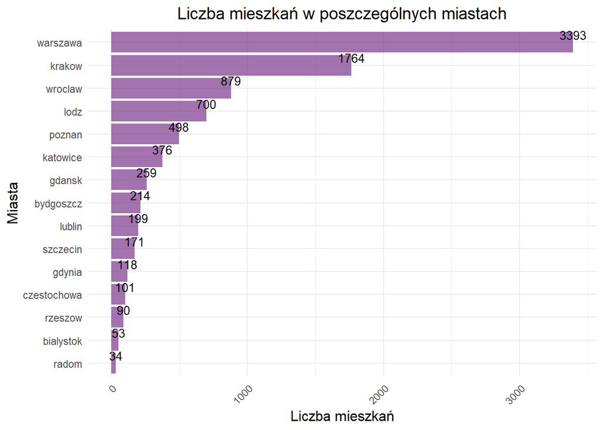

Wykres przedstawia liczbę mieszkań dostępnych w poszczególnych miastach Polski. Warszawa zdecydowanie przoduje z liczbą 3393 mieszkań, co pokazuje jej dominującą pozycję na rynku nieruchomości. Kraków zajmuje drugie miejsce z liczbą 1764 mieszkań, a Wrocław trzecie z 879, co odzwierciedla koncentrację ofert w największych aglomeracjach. Mniejsze miasta, takie jak Radom czy Białystok, mają znacznie mniejszą liczbę mieszkań, co może wynikać z ich wielkości, mniejszego zapotrzebowania na wynajem lub mniej rozwiniętego rynku nieruchomości.

1. Cena wynajmu vs. Odległość od centrum

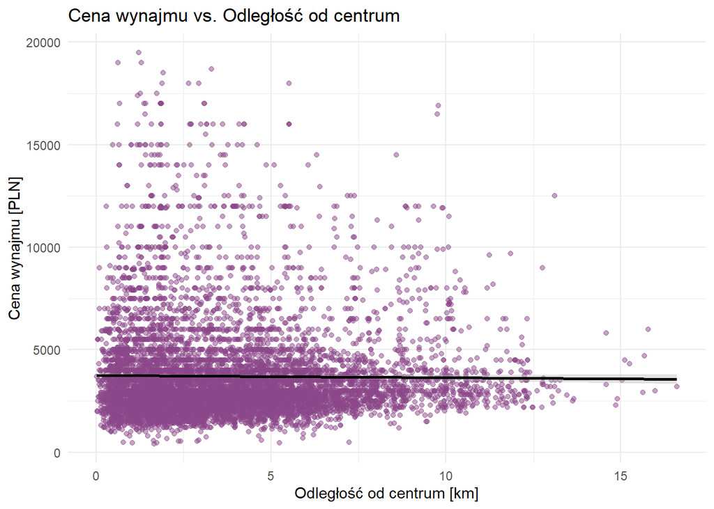

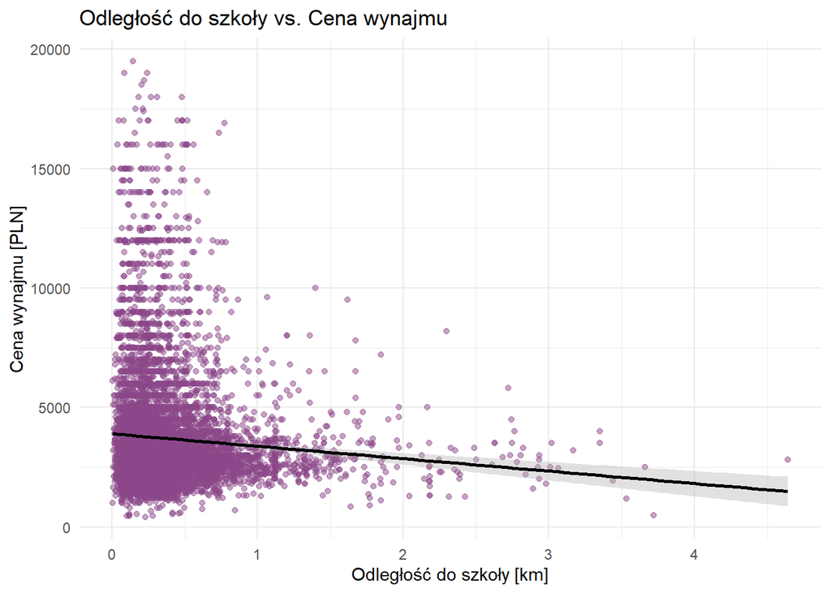